# SpatialAnalysisProject

Chung-Wing Ko

4/25/2022

## Load Libraries and Data

```r
#load libraries
#data cleaning
library(tidyr)
library(dplyr)
library(stringr)
#plotting
library(ggplot2)
library(MetBrewer) #color palette
library(tmap)
#spatial analysis
library(sf)
library(sp)
library(spatstat)
library(maptools)
library(rgdal)
library(raster)
library(gstat) #IDW
library(geoR)

#load plot coordinates
coords <- read.csv("/Users/chungwingko/Desktop/CCProject/coordinates - Sheet1.csv")
#load boundary
boundary <- st_read("/Users/chungwingko/Desktop/CCProject/Map/CCcutout.shp")
```

## Data Cleaning

### Attribute Data

```r
#load + clean root mass data
rootbiomass <- read.csv("/Users/chungwingko/Desktop/CCProject/DryRootMasses - Sheet1.csv")
rootbiomass <- rootbiomass %>% dplyr::select(ID, FT, Necromass, Total.root.biomass)
rootbiomass$PercentNecro <- rootbiomass$Necromass/rootbiomass$Total.root.biomass
rootbiomass <- rootbiomass[-c(91:98),]
rootbiomass$FT <- as.factor(rootbiomass$FT)

#load + clean TOC/TN data
TOC <- read.csv("/Users/chungwingko/Desktop/CCProject/TOC data - Sheet1.csv")
#already subtracted all blanks
#corrected W05-F-B by using W16-F-B (run same week)
#corrected W57-F-B by using 56-F-B (same week)
TOC <- TOC %>% dplyr::select(Sample.ID, TOC_corrected, TC_corrected, IC_corrected, TN_corrected) %>% drop_na()
#assigning NA to outliers: W06-F-C (all), W07-F-C (TOC, TC, TN), W07-NF-SE (TOC, TC, TN), W57-F-SE (TOC, TC), W21-F-SW (TOC, TC, TN)
TOC[TOC$Sample.ID == "W06-F-C",2:5] <- NA
TOC[TOC$Sample.ID == "W07-F-C", c(2, 3, 5)] <- NA
TOC[TOC$Sample.ID == "W07-NF-SE", c(2, 3, 5)] <- NA
TOC[TOC$Sample.ID == "W57-F-SE", c(2:3)] <- NA
TOC[TOC$Sample.ID == "W21-F-SW", c(2, 3, 5)] <- NA

TOC_F <- TOC[str_detect(TOC$Sample.ID, "-F-"),]
TOC_F <- TOC_F %>% rename(TOC.F = TOC_corrected,
                          TC.F = TC_corrected,
                          IC.F = IC_corrected,
                          TN.F = TN_corrected)
TOC_F$Sample.ID <- gsub("-F", "", as.character(TOC_F$Sample.ID))
TOC_F <- TOC_F %>% filter(!str_detect(Sample.ID, "-B"))

TOC_NF <- TOC[str_detect(TOC$Sample.ID, "-NF-"),]
TOC_NF <- TOC_NF %>% rename(TOC.NF = TOC_corrected,
                          TC.NF = TC_corrected,
                          IC.NF = IC_corrected,
                          TN.NF = TN_corrected)
TOC_NF$Sample.ID <- gsub("-NF", "", as.character(TOC_NF$Sample.ID))
TOC_NF <- TOC_NF %>% filter(!str_detect(Sample.ID, "-B"))

TOC_TN <- left_join(TOC_F, TOC_NF, by = c("Sample.ID"))
TOC_TN[TOC_TN < 0] <-0
TOC_TN <- TOC_TN %>% rename(ID = Sample.ID)

#import soil moisture data
soil_moisture <- read.csv("/Users/chungwingko/Desktop/CCProject/FreshSoilExtracts.xlsx - Inorg_microbial N_P_soil_mass.csv")
soil_moisture <- soil_moisture %>% rename(KCl.F = KCl.Fum.Soil.mass..g.,
                          KCl.NF = KCl.non.fum.Soil.mass..g.,
                          Bicarb.F = Bicarb.Fum.Soil.mass..g.,
                          Bicarb.NF = Bicarb.non.fum.Soil.mass..g.,
                          Percent.Dry.Soil = X..Dry.Soil)
soil_moisture <- soil_moisture %>% dplyr::select(ID, KCl.F, KCl.NF, Bicarb.F, Bicarb.NF, Percent.Dry.Soil)
soil_moisture$KCl.F <- soil_moisture$KCl.F * soil_moisture$Percent.Dry.Soil
soil_moisture$KCl.NF <- soil_moisture$KCl.NF * soil_moisture$Percent.Dry.Soil
soil_moisture$Bicarb.F <- soil_moisture$Bicarb.F * soil_moisture$Percent.Dry.Soil
soil_moisture$Bicarb.NF <- soil_moisture$Bicarb.NF * soil_moisture$Percent.Dry.Soil

#load + clean SEAL data
SEAL <- read.csv("/Users/chungwingko/Desktop/CCProject/Cleaned SEAL data - Sheet1.csv")
SEAL <- SEAL %>% dplyr::select(ID, NH3_corrected, NO3_corrected) #blanks subtracted
SEAL <- SEAL %>% rename(NH3 = NH3_corrected,
                        NO3 = NO3_corrected)

SEAL_F <- SEAL[str_detect(SEAL$ID, "-F-"),]
SEAL_F <- SEAL_F %>% rename(NH3.F = NH3,
                          NO3.F = NO3)
SEAL_F$ID <- gsub("-F", "", as.character(SEAL_F$ID))
SEAL_F <- SEAL_F %>% filter(!str_detect(ID, "-B"))

SEAL_NF <- SEAL[str_detect(SEAL$ID, "-NF-"),]
SEAL_NF <- SEAL_NF %>% rename(NH3.NF = NH3,
                          NO3.NF = NO3)
SEAL_NF$ID <- gsub("-NF", "", as.character(SEAL_NF$ID))
SEAL_NF <- SEAL_NF %>% filter(!str_detect(ID, "-B"))

SEAL <- left_join(SEAL_F, SEAL_NF, by = c("ID"))
SEAL[SEAL < 0] <-0

#join all datasets
CCProject <- left_join(TOC_TN, rootbiomass, by = "ID")
CCProject <- left_join(CCProject, SEAL, by = "ID")
CCProject <- left_join(CCProject, soil_moisture, by = "ID")
#separate plot and direction
CCProject <- CCProject %>% separate(ID, c("Plot", "Direction"))
#change variable order
CCProject <- CCProject %>% dplyr::select(FT, Plot, Direction,Total.root.biomass, PercentNecro, TOC.F, TOC.NF, TC.F, TC.NF, IC.F, IC.NF, TN.F, TN.NF, NH3.F, NH3.NF, NO3.F, NO3.NF, KCl.F, KCl.NF, Bicarb.F, Bicarb.NF)

#adjust all values for dry soil mass
CCProject$TOC.F = CCProject$TOC.F*25/CCProject$KCl.F
CCProject$TOC.NF = CCProject$TOC.NF*25/CCProject$KCl.NF
CCProject$TC.F = CCProject$TC.F*25/CCProject$KCl.F
CCProject$TC.NF = CCProject$TC.NF*25/CCProject$KCl.NF
CCProject$IC.F = CCProject$IC.F*25/CCProject$KCl.F
CCProject$IC.NF = CCProject$IC.NF*25/CCProject$KCl.NF
CCProject$TN.F = CCProject$TN.F*25/CCProject$KCl.F
CCProject$TN.NF = CCProject$TN.NF*25/CCProject$KCl.NF
CCProject$NH3.F = CCProject$NH3.F*25/CCProject$KCl.F
CCProject$NH3.NF = CCProject$NH3.NF*25/CCProject$KCl.NF
CCProject$NO3.F = CCProject$NO3.F*25/CCProject$KCl.F
CCProject$NO3.NF = CCProject$NO3.NF*25/CCProject$KCl.NF

CCProject$MicrobeC = (CCProject$TOC.F - CCProject$TOC.NF)/0.45
CCProject$microbeN = (CCProject$TN.F - CCProject$TN.NF)/0.54
```

### Filtering Soil Nitrogen Data

For this project, I’ll be focusing on interpolating soil nitrogen content across the lower Central Catchment region. Therefore, I’ll be using just the soil nitrogen measurements (in ppm), and all other data were used to help calculate concentrations and will not be needed.

```r
#for this project, focusing on soil nitrogen content
attributes <- CCProject %>% dplyr::select(Plot, Direction, TN.NF) %>% drop_na()
attributes <- attributes %>% group_by(Plot) %>% summarise(N = mean(TN.NF)) #averaging measurements
```

### Join Data

```r
#join coordinates and attributes
plots <- left_join(coords, attributes, by = "Plot")

#clean data
plots = dplyr::select(plots, -Plot)
plots.sf <- st_as_sf(plots, coords = c("y", "x"), crs = 4326)
attributes(plots.sf)
```

```
## $names
## [1] "N"        "geometry"
##
## $row.names
##  [1]  1  2  3  4  5  6  7  8  9 10 11 12 13 14 15 16 17 18
##
## $sf_column
## [1] "geometry"
##
## $agr
##    N
## <NA>
## Levels: constant aggregate identity
##
## $class
## [1] "sf"         "data.frame"
```

## Data Visualisation

### Using ggplot2

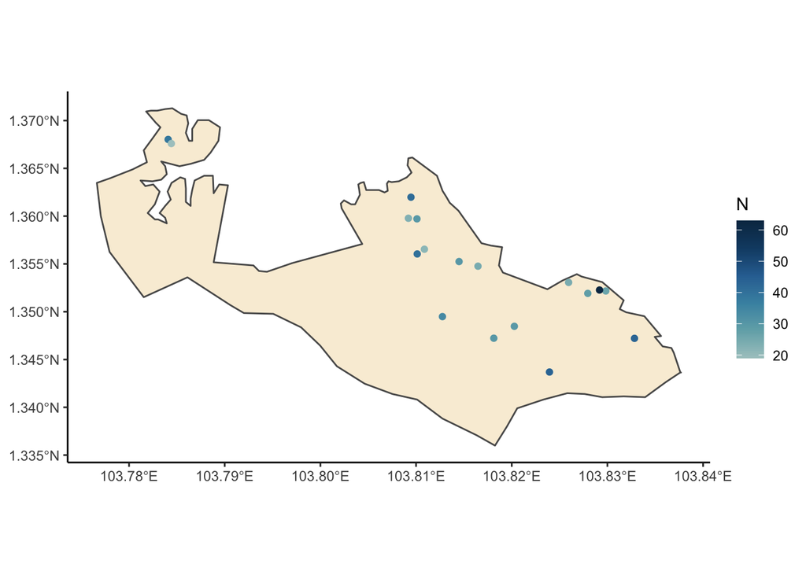

```r
#plot boundary and points
ggplot() +
  geom_sf(data = boundary, fill = "#F9EED9") +
  geom_sf(data = plots.sf, aes(color = N)) + scale_color_gradientn(colors = met.brewer("Hokusai2")) + theme_classic()
```

### Using tmap

```r
tmap_options(check.and.fix = TRUE)
#convert sf objects to SpatialPointsDataFrame
boundary.sp <- as(boundary, "Spatial")
plots.sf <- st_as_sf(plots, coords = c("y", "x"), crs = 4326)
plots.sp <- as(plots.sf, "Spatial")

class(boundary.sp)
```

```
## [1] "SpatialPolygonsDataFrame"
## attr(,"package")
## [1] "sp"
```

```r
class(plots.sp)
```

```
## [1] "SpatialPointsDataFrame"
## attr(,"package")
## [1] "sp"
```

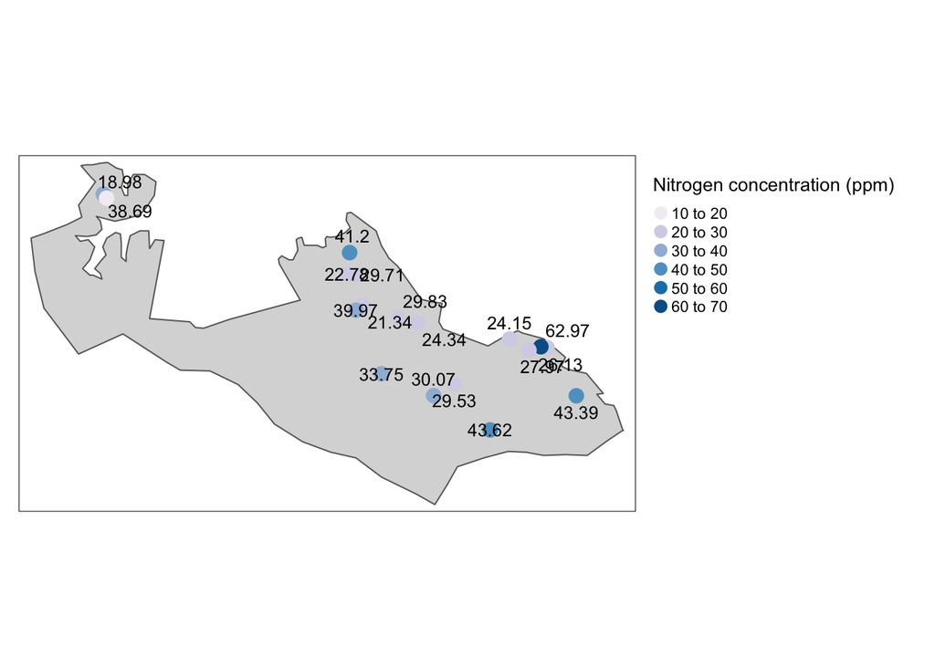

```r
#replace point boundary with that of polygon
plots.sp@bbox <- boundary.sp@bbox

#round to 2 decimals
plots.sp$N <- round(plots.sp$N, digit = 2)

#plot
tm_shape(boundary.sp) + tm_polygons() +
  tm_shape(plots.sp) +
  tm_dots(col="N", palette = "PuBu", title="Nitrogen concentration (ppm)", size=0.5) +
  tm_text("N", auto.placement =  TRUE, xmod=.5, size = .8) +
  tm_legend(legend.outside=TRUE)
```

```r
tmap_options(check.and.fix = TRUE)
```

## Inverse Distance Weighted (IDW)

The IDW method uses nearby locations to compute values for unsampled locations, weighting measurements based on proximity based on a universal power coefficient which applys equally to all coefficients.

### Interpolate

```r
#create an empty grid
grd <- as.data.frame(spsample(plots.sp, "regular", n=50000))
names(grd) <- c("x", "y")
coordinates(grd) <- c("x", "y")
gridded(grd) <- TRUE  #create SpatialPixel object
fullgrid(grd) <- TRUE  #create SpatialGrid object

#add projection info to the empty grid
proj4string(plots.sp) <- proj4string(plots.sp)
proj4string(grd) <- proj4string(plots.sp)

#interpolate the grid cells using a power value of 2
plots.idw <- gstat::idw(N ~ 1, plots.sp, newdata=grd, idp=2.0)
```

```
## [inverse distance weighted interpolation]
```

```r
#convert to raster object then clip to boundary
r <- raster(plots.idw)
r.m <- mask(r, boundary.sp)
```

### Plot

```r
#plot
tmap_mode("view") #interactive plot
tm_shape(r.m) +
  tm_raster(n=10, palette = "PuBu", auto.palette.mapping = FALSE,
            title="Predicted nitrogen concentration (ppm)") +
  tm_shape(plots.sp) + tm_dots(size=0.2) +
  tm_legend(legend.outside=TRUE)
```

[interactive chart not shown]

### Fine Tune Power Parameter

```r
#leave-one-out validation routine
IDW.out <- vector(length = length(plots.sp))
for (i in 1:length(plots.sp)) {
  IDW.out[i] <- gstat::idw(N ~ 1, plots.sp[-i,], plots.sp[i,], idp=2)$var1.pred
}
```

[output not shown]

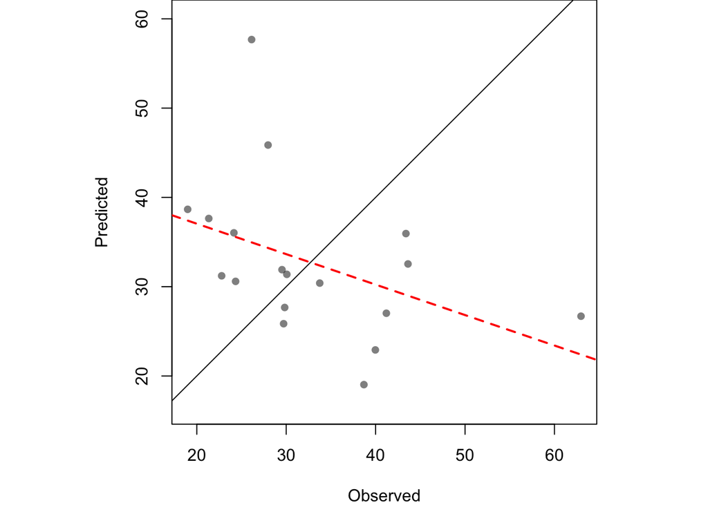

```r
#plot the differences
OP <- par(pty="s", mar=c(4,3,0,0))
plot(IDW.out ~ plots.sp$N, asp=1, xlab="Observed", ylab="Predicted", pch=16,
       col=rgb(0,0,0,0.5))
abline(lm(IDW.out ~ plots.sp$N), col="red", lw=2,lty=2)
  abline(0,1)
```

```r
par(OP)

#compute RMSE
sqrt( sum((IDW.out - plots.sp$N)^2) / length(plots.sp))
```

```
## [1] 16.03843
```

```r
#change power to 1
IDW.out1 <- vector(length = length(plots.sp))
for (i in 1:length(plots.sp)) {
  IDW.out1[i] <- gstat::idw(N ~ 1, plots.sp[-i,], plots.sp[i,], idp=1)$var1.pred
}
```

[output not shown]

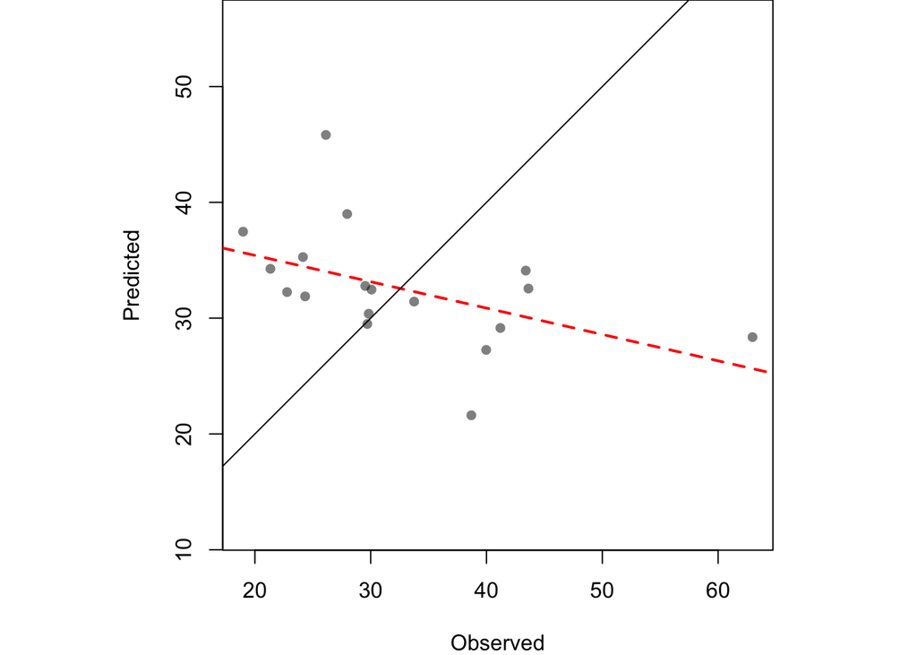

```r
#plot the differences
OP1 <- par(pty="s", mar=c(4,3,0,0))
plot(IDW.out1 ~ plots.sp$N, asp=1, xlab="Observed", ylab="Predicted", pch=16,
       col=rgb(0,0,0,0.5))
abline(lm(IDW.out1 ~ plots.sp$N), col="red", lw=2,lty=2)
  abline(0,1)
```

```r
par(OP1)

#compute RMSE
sqrt( sum((IDW.out1 - plots.sp$N)^2) / length(plots.sp))
```

```
## [1] 13.57086
```

```r
#change power to 0
IDW.out2 <- vector(length = length(plots.sp))
for (i in 1:length(plots.sp)) {
  IDW.out2[i] <- gstat::idw(N ~ 1, plots.sp[-i,], plots.sp[i,], idp=0)$var1.pred
}
```

[output not shown]

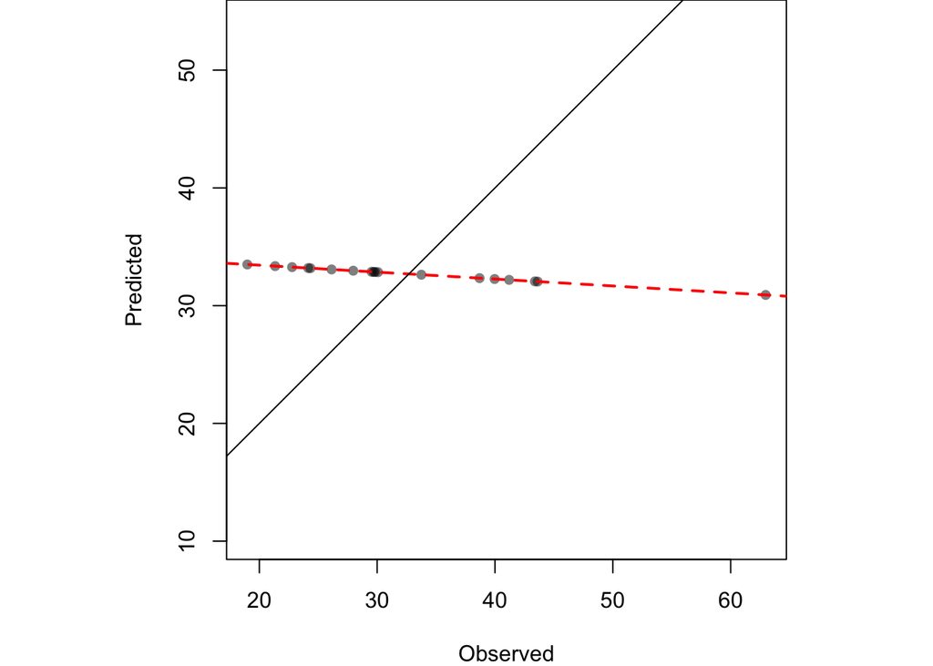

```r
#plot the differences
OP2 <- par(pty="s", mar=c(4,3,0,0))
plot(IDW.out2 ~ plots.sp$N, asp=1, xlab="Observed", ylab="Predicted", pch=16,
       col=rgb(0,0,0,0.5))
abline(lm(IDW.out2 ~ plots.sp$N), col="red", lw=2,lty=2)
  abline(0,1)
```

```r
par(OP2)

#compute RMSE
sqrt( sum((IDW.out2 - plots.sp$N)^2) / length(plots.sp))
```

```
## [1] 11.07765
```

The error got smaller as the power coefficient decreased, which gives all points within the search radius equal weight such that unsampled locations represent just the mean value of all sampled points within the search radius. This could be due to a wide variety of reasons, including that the spatial heterogeneity of the site is high, so even plots close together can have large differences in soil nitrogen content. Additionally, the points are not evenly spaced, and could influence some of these patterns. Overall, this implies that distance does not have a significant role in influencing measured soil nitrogen patterns.

### Cross Validation

We can generate a 95% confidence interval map to look at the interpolation model more visually.

```r
#create interpolated surface
img <- gstat::idw(N~1, plots.sp, newdata=grd, idp=3)
```

```
## [inverse distance weighted interpolation]
```

```r
n   <- length(plots.sp)
Zi  <- matrix(nrow = length(img$var1.pred), ncol = n)

#remove a point then interpolate (n times for each point)
st <- stack()
for (i in 1:n){
  Z1 <- gstat::idw(N~1, plots.sp[-i,], newdata=grd, idp=0)
  st <- addLayer(st,raster(Z1,layer=1))
  # calculated pseudo-value Z at j
  Zi[,i] <- n * img$var1.pred - (n-1) * Z1$var1.pred
}
```

[output not shown]

```r
#jackknife estimator of parameter Z at location j
Zj <- as.matrix(apply(Zi, 1, sum, na.rm=T) / n )

#compute (Zi* - Zj)^2
c1 <- apply(Zi,2,'-',Zj)            #compute the difference
c1 <- apply(c1^2, 1, sum, na.rm=T ) #sum the square of the difference

#compute the confidence interval
CI <- sqrt(1/(n*(n-1)) * c1)

#create (CI / interpolated value) raster
img.sig <- img
img.sig$v <- CI /img$var1.pred

#clip the confidence raster to polygon
r <- raster(img.sig, layer="v")
r.m <- mask(r, boundary.sp)

#plot the map
tm_shape(r.m) + tm_raster(n=7, palette = "PuBu", title="95% confidence interval (N content in ppm)") +
  tm_shape(plots.sp) + tm_dots(size=0.2) +
  tm_legend(legend.outside=TRUE)
```

[interactive chart not shown]

## Polynomial Fits

### 1st Order

```r
#define polynomial equation
f.1 <- as.formula(N ~ x + y)

#add X and Y to point data
plots.sp$x <- coordinates(plots.sp)[,1]
plots.sp$y <- coordinates(plots.sp)[,2]

#run the regression model
lm.1 <- lm(f.1, data=plots.sp)

#use the regression model output to interpolate the surface
dat.1st <- SpatialGridDataFrame(grd, data.frame(var1.pred = predict(lm.1, newdata=grd)))

#clip the interpolated raster to polygon
r <- raster(dat.1st)
r.m <- mask(r, boundary.sp)

#plot the map
tm_shape(r.m) +
  tm_raster(n=10, palette="PuBu", auto.palette.mapping=FALSE,
            title="Predicted nitrogen concentration (ppm)") +
  tm_shape(plots.sp) + tm_dots(size=0.2) +
  tm_legend(legend.outside=TRUE)
```

[interactive chart not shown]

### 2nd Order

```r
#define polynomial equation
f.2 <- as.formula(N ~ x + y + I(x*x)+I(y*y) + I(x*y))

#add X and Y to point data
plots.sp$x <- coordinates(plots.sp)[,1]
plots.sp$y <- coordinates(plots.sp)[,2]

#run the regression model
lm.2 <- lm(f.2, data=plots.sp)

#use the regression model output to interpolate the surface
dat.2nd <- SpatialGridDataFrame(grd, data.frame(var1.pred = predict(lm.2, newdata=grd)))

#clip the interpolated raster to polygon
r <- raster(dat.2nd)
r.m <- mask(r, boundary.sp)

#plot the map
tm_shape(r.m) +
  tm_raster(n=10, palette="PuBu", auto.palette.mapping=FALSE,
            title="Predicted nitrogen concentration (ppm)") +
  tm_shape(plots.sp) + tm_dots(size=0.2) +
  tm_legend(legend.outside=TRUE)
```

[interactive chart not shown]

## Kriging

### Create Variogram Model

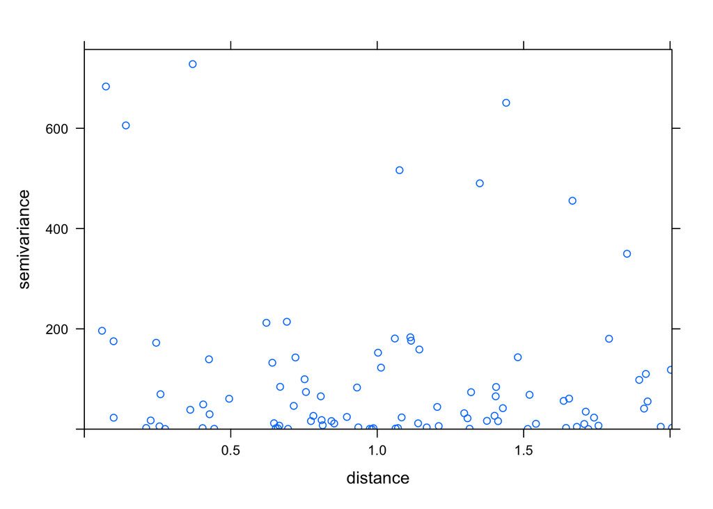

```r
#define polynomial equation
f.1 <- as.formula(N ~ x + y)

#experimental semivariogram cloud plot
var.smpl <- variogram(f.1, plots.sp, cloud = TRUE)
plot(var.smpl, fit.ranges = TRUE, fit.sills = TRUE)
```

```r
#sample variogram (cutoff and width based on cloud plot)
var.smpl <- variogram(f.1, plots.sp, cloud = FALSE, cutoff=2.5, width=.1)

#calculate parameters
max(var.smpl$dist)/3 #range
```

```
## [1] 0.8119922
```

```r
head(var.smpl$gamma, n = 3)
```

```
## [1] 351.61825 314.28503  44.60731
```

```r
(351.61825 + 314.28503 + 44.60731)/3 #nugget
```

```
## [1] 236.8369
```

```r
tail(var.smpl$gamma, n = 5)
```

```
## [1] 193.50258  66.81129 128.79986 219.20664  96.66212
```

```r
(4.843825 + 139.391291 + 78.058451  + 6.959237+ 277.066504)/5 #partial sill
```

```
## [1] 101.2639
```

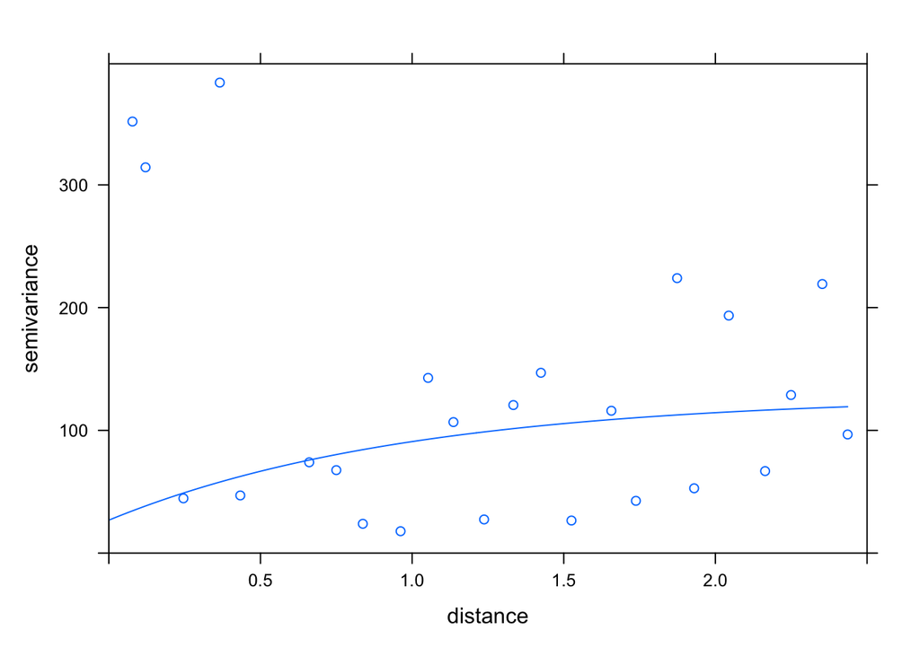

```r
#compute variogram model
dat.fit  <- fit.variogram(var.smpl, fit.ranges = FALSE, fit.sills = FALSE,
                          vgm(psill=101.2639, model="Exp", range=1, nugget=26.8369))
#assess fit
plot(var.smpl, dat.fit, xlim=c(0,2.5))
```

### Generate Kriged Surface

```r
#define model
f.1 <- as.formula(N ~ x + y)

#perform interpolation
dat.krg <- krige(f.1, plots.sp, grd, dat.fit)
```

```
## [using universal kriging]
```

```r
#convert kriged surface to a raster object for clipping
r <- raster(dat.krg)
r.m <- mask(r, boundary.sp)

#plot
tm_shape(r.m) +
  tm_raster(n=10, palette="PuBu", auto.palette.mapping=FALSE,
            title="Predicted nitrogen  concentration (ppm)") +
  tm_shape(plots.sp) + tm_dots(size=0.2) +
  tm_legend(legend.outside=TRUE)
```

[interactive chart not shown]

### Variance Map

```r
r <- raster(dat.krg, layer="var1.var")
r.m <- mask(r, boundary.sp)

#plot
tm_shape(r.m) +
  tm_raster(n=7, palette ="Reds",
            title="Variance map \n(in squared ppm)") + tm_shape(plots.sp) + tm_dots(size=0.2) +
  tm_legend(legend.outside=TRUE)
```

[interactive chart not shown]

### 95% Confidence Interval Map

```r
r <- sqrt(raster(dat.krg, layer="var1.var")) * 1.96
r.m <- mask(r, boundary.sp)

tm_shape(r.m) +
  tm_raster(n=7, palette ="Reds",
            title="95% CI map \n(in ppm)") +tm_shape(plots.sp) + tm_dots(size=0.2) +
  tm_legend(legend.outside=TRUE)
```

[interactive chart not shown]